# Olympic games data proccessing

## Data downloading

First of all I have downloaded row data by this [link](https://stepik.org/media/attachments/lesson/603865/athlete_events.zip). In this project we are going to process data, containing information about Olympic Games for past 120 years. In common case we have 15 variables which are described [here](https://stepik.org/media/attachments/lesson/603865/features_description.txt). These variables contain information about sportsman and Olympic Games of the year both. Author have changed some variables, that will be shown below.

## First step: merging files

Yet Olympic Games took place, the data must be uploaded. That is why I have written a function, that merges any files which extension is available in R. I will use pipelines, so before define the function I turn on the `dplyr` package by command `library()`

```r
library(dplyr)
```

```r
merge_csv <- function(path_to_folder, extention = 'csv'){
  setwd(path_to_folder)
  fun = paste('read', extention, sep='.')
  all_csv <- list.files(path = path_to_folder) %>% lapply(fun) %>% bind_rows
}
```

Speaking about `path_to_folder` variable, you need to input in it the whole path to directory where the files you want to merge are stored. Furthermore, it **must** be a string. Default value of variable `extension` is ‘.csv’, but you can define another extension, if there is a function `read.extension` in basic R.

## EAD

Let’s take a look on our data. First we need to call the function with proper values. As I’m using ‘.csv’ files, extension is being unchanged. Then just call `str()` and `summary()` functions on data.

```r
data <- merge_csv(path_to_file)
```

```r
str(data)
```

```
## 'data.frame':    271115 obs. of  15 variables:
##  $ ID    : int  1 2 3 4 5 5 5 5 5 5 ...
##  $ Name  : chr  "A Dijiang" "A Lamusi" "Gunnar Nielsen Aaby" "Edgar Lindenau Aabye" ...
##  $ Sex   : chr  "M" "M" "M" "M" ...
##  $ Age   : int  24 23 24 34 21 21 25 25 27 27 ...
##  $ Height: int  180 170 NA NA 185 185 185 185 185 185 ...
##  $ Weight: num  80 60 NA NA 82 82 82 82 82 82 ...
##  $ Team  : chr  "China" "China" "Denmark" "Denmark/Sweden" ...
##  $ NOC   : chr  "CHN" "CHN" "DEN" "DEN" ...
##  $ Games : chr  "1992 Summer" "2012 Summer" "1920 Summer" "1900 Summer" ...
##  $ Year  : int  1992 2012 1920 1900 1988 1988 1992 1992 1994 1994 ...
##  $ Season: chr  "Summer" "Summer" "Summer" "Summer" ...
##  $ City  : chr  "Barcelona" "London" "Antwerpen" "Paris" ...
##  $ Sport : chr  "Basketball" "Judo" "Football" "Tug-Of-War" ...
##  $ Event : chr  "Basketball Men's Basketball" "Judo Men's Extra-Lightweight" "Football Men's Football" "Tug-Of-War Men's Tug-Of-War" ...
##  $ Medal : chr  NA NA NA "Gold" ...
```

As it was told, we have 15 variables of different types. Also there are some ‘NA’ values. During next steps I will use `na.rm()` to remove them. Now it is time to get breef description of data.

```r
summary(data)
```

```
##        ID             Name               Sex                 Age
##  Min.   :     1   Length:271115      Length:271115      Min.   : 10.00
##  1st Qu.: 34643   Class :character   Class :character   1st Qu.: 21.00
##  Median : 68205   Mode  :character   Mode  :character   Median : 24.00
##  Mean   : 68249                                         Mean   : 25.56
##  3rd Qu.:102097                                         3rd Qu.: 28.00
##  Max.   :135571                                         Max.   :240.00
##                                                         NA's   :9476
##      Height          Weight          Team               NOC
##  Min.   :127.0   Min.   :  7.0   Length:271115      Length:271115
##  1st Qu.:168.0   1st Qu.: 60.0   Class :character   Class :character
##  Median :175.0   Median : 70.0   Mode  :character   Mode  :character
##  Mean   :175.3   Mean   : 70.7
##  3rd Qu.:183.0   3rd Qu.: 79.0
##  Max.   :340.0   Max.   :214.0
##  NA's   :60172   NA's   :62876
##     Games                Year         Season              City
##  Length:271115      Min.   :1896   Length:271115      Length:271115
##  Class :character   1st Qu.:1960   Class :character   Class :character
##  Mode  :character   Median :1988   Mode  :character   Mode  :character
##                     Mean   :1978
##                     3rd Qu.:2002
##                     Max.   :2016
##                     NA's   :7
##     Sport              Event              Medal
##  Length:271115      Length:271115      Length:271115
##  Class :character   Class :character   Class :character
##  Mode  :character   Mode  :character   Mode  :character
##
##
##
##
```

## Suspicious data removing

First assumption is that duplicates are present in the data. Furthermore, there is three suspicious values in “Age”, “Weight” and “Height”. Let’s correct the data

```r
data<- data[!duplicated(data),]
bad_rows <- data %>%
  filter(Age == 240 | Height == 340 | Weight == 7) %>%
  select(ID) %>% unlist()
```

We have dropped duplicates and also get number of ID, where the suspicious values are located. Let’s observe it.

```r
bad_rows
```

```
##   ID1   ID2   ID3
## 23459 23549 68370
```

```r
for (i in bad_rows){
  print(data %>% filter(ID == i))
}
```

```
##      ID                       Name Sex Age Height Weight    Team NOC
## 1 23459 Flicien Jules mile Courbet   M  20     NA     NA Belgium BEL
## 2 23459 Flicien Jules mile Courbet   M  24     NA     NA Belgium BEL
## 3 23459 Flicien Jules mile Courbet   M 240     NA     NA Belgium BEL
## 4 23459 Flicien Jules mile Courbet   M  24     NA     NA Belgium BEL
## 5 23459 Flicien Jules mile Courbet   M  32     NA     NA Belgium BEL
## 6 23459 Flicien Jules mile Courbet   M  32     NA     NA Belgium BEL
##         Games Year Season      City      Sport
## 1 1908 Summer 1908 Summer    London   Swimming
## 2 1912 Summer 1912 Summer Stockholm Water Polo
## 3 1912 Summer 1912 Summer Stockholm   Swimming
## 4 1912 Summer 1912 Summer Stockholm   Swimming
## 5 1920 Summer 1920 Summer Antwerpen   Swimming
## 6 1920 Summer 1920 Summer Antwerpen   Swimming
##                                    Event  Medal
```

[output cut: 67 more lines]

For the first “ID” it seems, that we can just delete this row, because there is no valuable information. For second and third “ID” the suspicious values can be restored after obervation.

```r
data<- data[-c(45239),]
data$Height[data$ID == 23549] <- 176
data$Weight[data$ID == 68370] <- 77
```

Let’s take a look again.

```r
summary(data)
```

```
##        ID             Name               Sex                 Age
##  Min.   :     1   Length:269729      Length:269729      Min.   :10.00
##  1st Qu.: 34656   Class :character   Class :character   1st Qu.:21.00
##  Median : 68233   Mode  :character   Mode  :character   Median :24.00
##  Mean   : 68265                                         Mean   :25.45
##  3rd Qu.:102111                                         3rd Qu.:28.00
##  Max.   :135571                                         Max.   :97.00
##                                                         NA's   :9317
##      Height          Weight          Team               NOC
##  Min.   :127.0   Min.   : 25.0   Length:269729      Length:269729
##  1st Qu.:168.0   1st Qu.: 60.0   Class :character   Class :character
##  Median :175.0   Median : 70.0   Mode  :character   Mode  :character
##  Mean   :175.3   Mean   : 70.7
##  3rd Qu.:183.0   3rd Qu.: 79.0
##  Max.   :226.0   Max.   :214.0
##  NA's   :58814   NA's   :61527
##     Games                Year         Season              City
##  Length:269729      Min.   :1896   Length:269729      Length:269729
##  Class :character   1st Qu.:1960   Class :character   Class :character
##  Mode  :character   Median :1988   Mode  :character   Mode  :character
##                     Mean   :1979
##                     3rd Qu.:2002
##                     Max.   :2016
##                     NA's   :7
##     Sport              Event              Medal
##  Length:269729      Length:269729      Length:269729
##  Class :character   Class :character   Class :character
##  Mode  :character   Mode  :character   Mode  :character
##
##
##
##
```

Looks better. Now I would like to check column “Sex” for mistakes. I will use unique() function to collect all **unique** **values**.

```r
data %>% select(Sex) %>% unique()
```

```
##        Sex
## 1        M
## 5        F
## 158594   G
## 226260
```

It seems, that we have some mistakes in data. G I will replace by M, row without “Sex” I will delete.

```r
data["Sex"][data["Sex"] == "G"] <- "M"
data <- data %>% filter(Sex != "")
```

So the data is ready for further processing.

## Tasks

In this part I will perform the tasks given in this [link](https://stepik.org/media/attachments/lesson/603865/%D0%9F%D1%80%D0%BE%D0%B5%D0%BA%D1%82_1_.pdf). I will rewrite each task in *italics* before performing.

### Task №1

*Find out the age of the youngest athletes of both sexes at the 1992 Olympics.*

```r
minF <- min(data$Age[data$Year == 1992 & data$Sex == "F"], na.rm = TRUE)
minM <- min(data$Age[data$Year == 1992 & data$Sex == "M"], na.rm = TRUE)
minF; minM
```

```
## [1] 12
```

```
## [1] 11
```

As minF and minM was subset by “Sex”, we can see that the youngest girl was 12 y.o. and the youngest boy was 11 y.o.

### Task №2

*Calculate the mean and standard deviation of the Height variable for athletes of each gender.*

```r
data_m <-  data %>% filter(data$Sex == "M")
data_f <-  data %>% filter(data$Sex == "F")
mean_all <- c(male_mean = mean(data_m$Height, na.rm = TRUE),
              fmale_mean = mean(data_f$Height, na.rm = TRUE))
sd_all <- c(male_sd = sd(data_m$Height, na.rm = TRUE),
            fmale_sd = sd(data_f$Height, na.rm = TRUE))
mean_all; sd_all
```

```
##  male_mean fmale_mean
##   178.8593   167.8397
```

```
##  male_sd fmale_sd
## 9.360060 8.778463
```

### Task №3

*Calculate the mean and standard deviation of the Height variable for female tennis players (sex = F) at the 2000 Olympics. Round your answer to the first decimal place after the dot.*

```r
ten_f_height <- data %>% filter(Year == 2000) %>% filter(Sex == "F") %>% filter(Sport == "Tennis") %>%
  select(Height) %>% unlist()
ten_f_mean <- round(mean(ten_f_height, na.rm = TRUE), digits = 1)
ten_f_sd <- round(sd(ten_f_height, na.rm = TRUE), digits = 1)
ten_f_mean; ten_f_sd
```

```
## [1] 171.8
```

```
## [1] 6.5
```

### Task №4

*What sport did the heaviest athlete compete in at the 2006 Olympics?*

```r
people_2006 <-  data %>% filter(Year == 2006)
max_weight <- max(people_2006$Weight, na.rm = TRUE)
heav_man_sport <- people_2006 %>% filter(Weight == max_weight) %>% select(Sport) %>% unlist()
heav_man_sport
```

```
##      Sport
## "Skeleton"
```

### Task №5

*How many gold medals were won by women between 1980 and 2010?*

```r
gold_females <- data %>% filter(Year >= 1980 & Year <= 2010) %>%
  filter(Sex == "F") %>% filter(Medal == "Gold") %>% select(Medal) %>% unlist() %>% length()
gold_females
```

```
## [1] 2249
```

### Task №6

*How many times has John Aalberg competed in the Olympics in different years?*

```r
John_Alberg_took_part <- data %>% filter(Name == "John Aalberg") %>%
  select(Year) %>% unique
length(John_Alberg_took_part$Year)
```

```
## [1] 2
```

### Task №7

*Determine the least and most represented (by number of participants) age groups of athletes at the 2008 Olympics.*

```r
Oli_2008_age <- data %>% filter(Year == 2008)
# range(Oli_2008_age$Age, na.rm = TRUE)
group_10 <- Oli_2008_age %>% filter(Age >= 10 & Age < 20)
group_20 <- Oli_2008_age %>% filter(Age >= 20 & Age < 30)
group_30 <- Oli_2008_age %>% filter(Age >= 30 & Age < 40)
group_40 <- Oli_2008_age %>% filter(Age >= 40 & Age < 50)
group_50 <- Oli_2008_age %>% filter(Age >= 50 & Age < 60)
group_60 <- Oli_2008_age %>% filter(Age >= 60 & Age < 70)
group_10_sports <- group_10 %>% select(Name) %>% unique() %>% as.vector() %>% unlist
group_20_sports <- group_20 %>% select(Name) %>% unique() %>% as.vector() %>% unlist
group_30_sports <- group_30 %>% select(Name) %>% unique() %>% as.vector() %>% unlist
group_40_sports <- group_40 %>% select(Name) %>% unique() %>% as.vector() %>% unlist
group_50_sports <- group_50 %>% select(Name) %>% unique() %>% as.vector() %>% unlist
group_60_sports <- group_60 %>% select(Name) %>% unique() %>% as.vector() %>% unlist
g1l <- length(group_10_sports)
g2l <- length(group_20_sports)
g3l <- length(group_30_sports)
g4l <- length(group_40_sports)
g5l <- length(group_50_sports)
g6l <- length(group_60_sports)
ls = c(g1 = g1l, g2 =  g2l, g3 =  g3l,
       g4 = g4l, g5 =  g5l, g6 = g6l)
ls[which.max(ls)]; ls[which.min(ls)]
```

```
##   g2
## 7509
```

```
## g6
##  4
```

By `range()` I fave determined min and max value in “Age” to make groups with same spacing. So the most represented group in 2008 consists of sportsman between 20 and 30 y.o., whereas the less represented group in 2008 consists of sportsman between 60 and 70 y.o.

### Task №8

*How much has the number of sports changed in the 2002 Olympics compared to the 1994 Olympics?*

```r
Oli2002 <- data %>% filter(Year == 2002) %>% select(Sport) %>% unique()
Oli1994 <- data %>% filter(Year == 1994) %>% select(Sport) %>% unique()
dif_in_sports <- c("Difference in the number of sports" = length(Oli2002$Sport) - length(Oli1994$Sport))
dif_in_sports
```

```
## Difference in the number of sports
##                                  3
```

### Task №9

*Output for the winter and summer Olympiad separately the top 3 countries for each type of medals.*

```r
medals <- data %>% filter(!is.na(Medal)&!is.na(Season))
medal_freq <- data.frame(table(medals$Medal, medals$Season, medals$NOC))
head(medal_freq)
```

```
##     Var1   Var2 Var3 Freq
## 1                       2
## 2 Bronze                0
## 3   Gold                0
## 4 Silver                0
## 5        Summer         0
## 6 Bronze Summer         0
```

### Task №10

*Create a new Height_z_scores variable and store the values of the Height variable into it after it has been standardized.*

```r
Height_z_scores <- scale(data$Height)
```

### Task №11

*Create a new variable Height_min_max_scaled and save the values of the variable Height into it after applying min-max normalization to it.*

```r
min_max_scale <- function(x){
  (x- min(x, na.rm = TRUE)) /(max(x, na.rm = TRUE)-min(x, na.rm = TRUE))
}

Height_min_max_scaled <- data %>% select(Height) %>% lapply(min_max_scale)
str(Height_min_max_scaled)
```

```
## List of 1
##  $ Height: num [1:269727] 0.535 0.434 NA NA 0.586 ...
```

### Task №12

*Compare the height, weight, and age of men and women who competed in the Winter Olympics. Please format the results so that we can immediately use them for the article.*

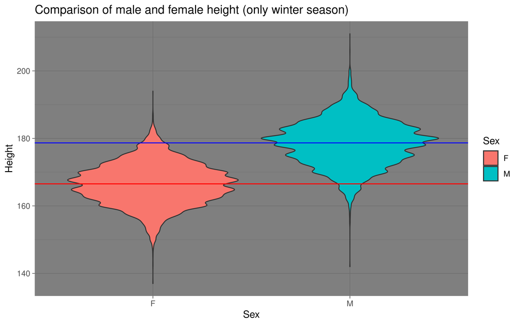

```r
winter_games <- data %>% filter(Season == "Winter")
library(ggplot2)
ggplot(winter_games, aes(x = Sex, y = Height, fill = Sex))+
  geom_violin()+
  geom_hline(yintercept = mean(winter_games$Height[winter_games$Sex == "M"], na.rm = T),
             color = "blue")+
  geom_hline(yintercept = mean(winter_games$Height[winter_games$Sex == "F"], na.rm = T),
             color = "red")+
  labs(title = "Comparison of male and female height (only winter season)")+
  theme_dark()
```

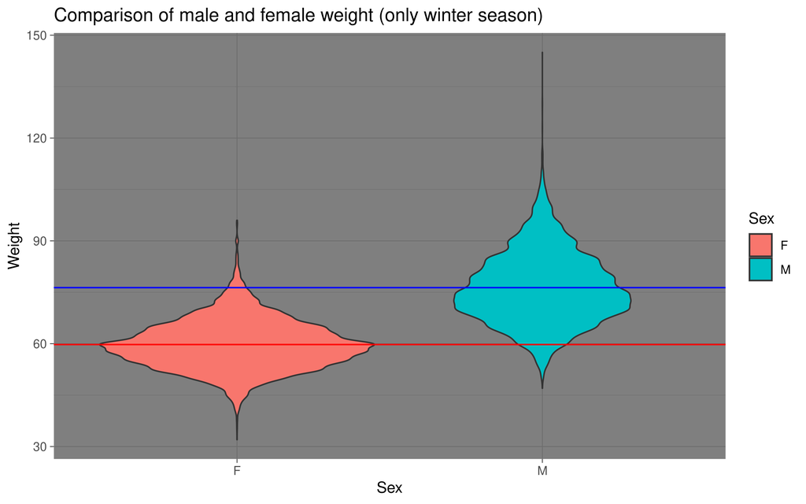

```r
ggplot(winter_games, aes(x = Sex, y = Weight, fill = Sex))+
  geom_violin()+
  geom_hline(yintercept = mean(winter_games$Weight[winter_games$Sex == "M"], na.rm = T),
             color = "blue")+
  geom_hline(yintercept = mean(winter_games$Weight[winter_games$Sex == "F"], na.rm = T),
             color = "red")+
  labs(title = "Comparison of male and female weight (only winter season)")+
  theme_dark()
```

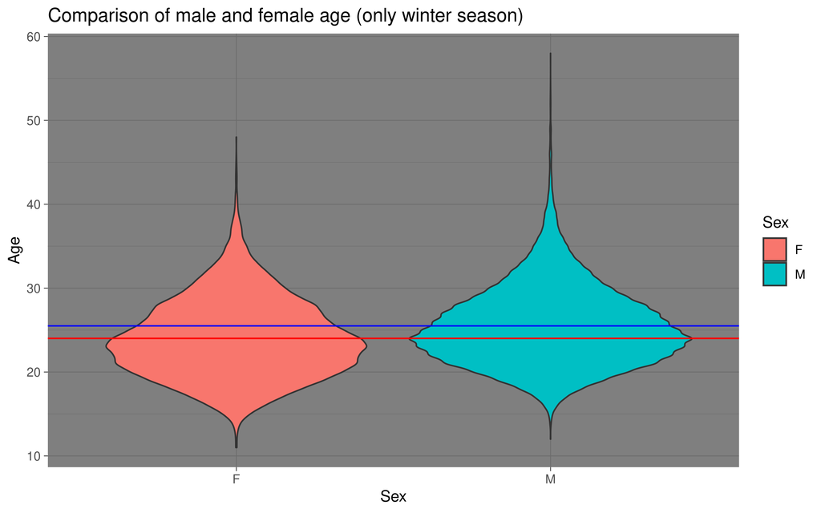

```r
ggplot(winter_games, aes(x = Sex, y = Age, fill = Sex))+
  geom_violin()+
  geom_hline(yintercept = mean(winter_games$Age[winter_games$Sex == "M"], na.rm = T),
             color = "blue")+
  geom_hline(yintercept = mean(winter_games$Age[winter_games$Sex == "F"], na.rm = T),
             color = "red")+
  labs(title = "Comparison of male and female age (only winter season)")+
  theme_dark()
```

### Task №13

*We are especially interested in the Team and Medal variables. What can you say about them? Do we have reason to believe that they may be related? How did you define it?*

We need to investigate relationship between “Team” and “Medal” variables. These variables are categorical and the number of observations are quit huge, what allows me to use chi-square test. H0 is that variables are independent. If p.value < 0.05 - the variables are dependent.

```r
Noc_medal <- data %>% select(c(Medal, NOC)) %>% na.omit()
chisq_res <- chisq.test(Noc_medal$Medal, Noc_medal$NOC)
chisq_res$p.value; chisq_res$statistic; summary(chisq_res)
```

```
## [1] 0
```

```
## X-squared
##  27862.89
```

```
##           Length Class  Mode
## statistic   1    -none- numeric
## parameter   1    -none- numeric
## p.value     1    -none- numeric
## method      1    -none- character
## data.name   1    -none- character
## observed  608    table  numeric
## expected  608    -none- numeric
## residuals 608    table  numeric
## stdres    608    table  numeric
```